# 1. Finding co-accessible modules in CD4-T using Cicero

Paula Soler-Vila

22 November 2021

# 1 Objective

The objective of this notebook is to use [Cicero][https://cole-trapnell-lab.github.io/cicero-release/docs_m3/#constructing-cis-regulatory-networks] to build a genome-wide cis-regulatory map.

# 2 Pre-processing

## 2.1 Load packages

```r
library(Signac)
library(Seurat)
library(SeuratWrappers)
library(ggplot2)
library(patchwork)
library(cicero)
library(EnsDb.Hsapiens.v86)
library(ggpubr)
library(lattice)
library(tidyr)
library(MASS)
library(factoextra)
library(plyr)
library(reshape2)
library(pheatmap)
library(stringr)
```

## 2.2 Parameters

```r
cell_type <- "CD4_T"

path_to_obj <- str_c(
  here::here("scATAC-seq/results/R_objects/level_5/"),
  cell_type,
  "/04.",
  cell_type,
  "_integration_peak_calling_level_5.rds",
  sep = ""
)

color_palette<- c("black", "gray", "red", "yellow", "violet", "green4",
                  "blue", "chocolate1", "coral2", "blueviolet",
                  "brown1", "darkmagenta", "deepskyblue1", "dimgray",
                  "deeppink1", "green", "lightgray", "hotpink1",
                  "indianred4", "khaki", "mediumorchid2")

path_to_save <- str_c(
  here::here("scATAC-seq/results/Cicero/"),
  cell_type,"/",
  sep = ""
)
```

## 2.3 Load data

Cicero uses the normalized scATAC data integrated by Harmony. We are going to start the analysis by visualizing the main clusters defined in level 4 thanks to the scRNAseq that will become our idents.

```r
seurat <- readRDS(path_to_obj)
seurat
```

```
## An object of class Seurat
## 93116 features across 16383 samples within 1 assay
## Active assay: peaks_level_5 (93116 features, 92407 variable features)
##  3 dimensional reductions calculated: umap, lsi, harmony
```

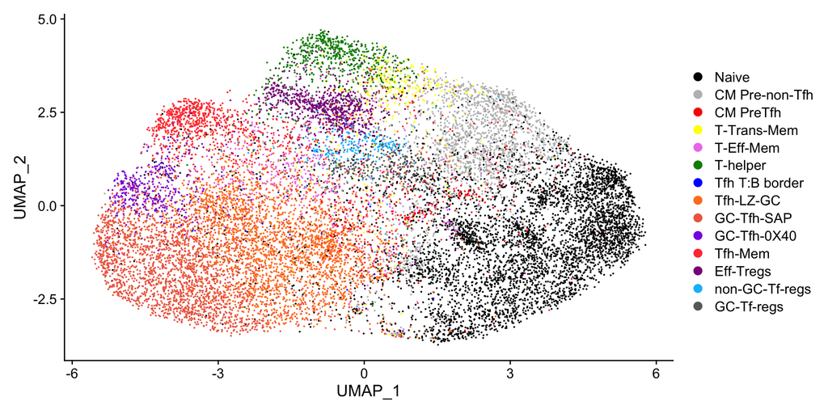

```r
Idents(seurat) <- seurat$annotation_paper

DimPlot(
  seurat,
  cols = color_palette,
  pt.size = 0.1
)
```

# 3 Get annotations

First, we need to extract the lenght of the chromosomes (be aware that we are using from EnsDb the hg38 as the reference human assembly)

```r
annotations <- GetGRangesFromEnsDb(ensdb = EnsDb.Hsapiens.v86)
seqlevelsStyle(annotations) <- "UCSC"
genome(annotations) <- "hg38"

# get the chromosome sizes from the Seurat object
genome <- seqlengths(annotations)

# convert chromosome sizes to a dataframe
genome.df <- data.frame("chr" = names(genome), "length" = genome)

# Removing the chrM
genome.df <- genome.df[1:nrow(genome.df)-1,]
genome.df
```

```
##         chr    length
## chrX   chrX 156040895
## chr20 chr20  64444167
## chr1   chr1 248956422
## chr6   chr6 170805979
## chr3   chr3 198295559
## chr7   chr7 159345973
## chr12 chr12 133275309
## chr11 chr11 135086622
## chr4   chr4 190214555
## chr17 chr17  83257441
## chr2   chr2 242193529
## chr16 chr16  90338345
## chr8   chr8 145138636
## chr19 chr19  58617616
## chr9   chr9 138394717
## chr13 chr13 114364328
## chr14 chr14 107043718
## chr5   chr5 181538259
## chr22 chr22  50818468
## chr10 chr10 133797422
## chrY   chrY  57227415
## chr18 chr18  80373285
## chr15 chr15 101991189
## chr21 chr21  46709983
```

# 4 CICERO

## 4.1 Convert to CellDataSet format and make the cicero object.

```r
seurat.cds <- as.cell_data_set(x = seurat)
seurat.cds
```

```
## class: cell_data_set
## dim: 93116 16383
## metadata(0):
## assays(2): counts logcounts
## rownames(93116): chr1-10032-10367 chr1-181323-181575 ... chrY-26670486-26670742 chrY-26671034-26671234
## rowData names(0):
## colnames(16383): AAACGAAAGAAACGCC-2 AAACGAAAGAATATCG-4 ... sr20954q_yiuuoxng_TTTGTTGGTAAATTGC-1 sr20954q_yiuuoxng_TTTGTTGGTCATAACG-1
## colData names(69): gem_id scrublet_doublet_scores_atac ... ident Size_factor
## reducedDimNames(3): UMAP LSI HARMONY
## altExpNames(0):
```

```r
seurat.cicero <- make_cicero_cds(seurat.cds, reduced_coordinates = reducedDims(seurat.cds)$HARMONY)
seurat.cicero
```

```
## class: cell_data_set
## dim: 93116 5001
## metadata(1): cds_version
## assays(1): counts
## rownames(93116): chr1-10032-10367 chr1-181323-181575 ... chrY-26670486-26670742 chrY-26671034-26671234
## rowData names(5): num_cells_expressed chr bp1 bp2 Peak
## colnames(5001): agg7951 agg1378 ... agg258 agg15744
## colData names(3): agg_cell Size_Factor num_genes_expressed
## reducedDimNames(0):
## altExpNames(0):
```

## 4.2 Run main function

The run_cicero function is a wrapper that runs the primary functions of the Cicero pipeline with default parameters such as:

1. estimate_distance_parameter. This function calculates the distance penalty parameter based on small random windows of the genome.
2. generate_cicero_models. This function uses the distance parameter determined above and uses graphical LASSO to calculate the co-accessibility scores of overlapping windows of the genome using a distance-based penalty.
3. assemble_connections. This function takes as input the output of generate_cicero_models and reconciles the overlapping models to create the final list of co-accessibility scores.

```r
conns <- run_cicero(seurat.cicero,
                    genomic_coords = genome.df,
                    sample_num = 100)
```

```
## [1] "Starting Cicero"
## [1] "Calculating distance_parameter value"
## [1] "Running models"
## [1] "Assembling connections"
## [1] "Successful cicero models:  8763"
## [1] "Other models: "
##
## Zero or one element in range
##                         3603
## [1] "Models with errors:  0"
## [1] "Done"
```

```r
write.table(x = conns,
            file = paste0(path_to_save,
                          "level_5_conns.tsv"),
            row.names = F, quote = F)
```

## 4.3 Find co-accessible networks

Now that we’ve found pairwise co-accessibility scores for each peak, we can now group these pairwise connections (using Louvain-based clustering algorithm) into larger co-accessible networks using the generate_ccans() function from Cicero. CCANS are modules of sites that are highly co-accessible with one another.

```r
ccans <- generate_ccans(conns)
```

```
## [1] "Coaccessibility cutoff used: 0.06"
```

```r
print(paste("Number of chromatin networks:",max(ccans$CCAN)))
```

```
## [1] "Number of chromatin networks: 4905"
```

```r
ccans_sorted <- ccans[order(-ccans$CCAN),]
head(ccans_sorted)
```

```
##                                      Peak CCAN
## chrY-8088674-8089273 chrY-8088674-8089273 4905
## chrY-8442082-8442487 chrY-8442082-8442487 4905
## chrY-8466745-8467549 chrY-8466745-8467549 4905
## chrY-8489096-8490825 chrY-8489096-8490825 4905
## chrY-7239900-7240557 chrY-7239900-7240557 4903
## chrY-7273457-7274234 chrY-7273457-7274234 4903
```

```r
write.table(x = ccans_sorted,
file = paste0(path_to_save, "level_5_ccans.tsv"),
row.names = F, quote = F)
```

## 4.4 Add links to a Seurat object

```r
conns <- read.table(paste0(path_to_save,"level_5_conns.tsv"),
                              header = T)
ccans <- read.table(paste0(path_to_save,"level_5_ccans.tsv"),
                              header = T)

links <- ConnectionsToLinks(conns = conns, ccans = ccans)
Links(seurat) <- links

write.table(x = links,
file = paste0(path_to_save, "level_5_links.tsv"),
row.names = F, quote = F)
```

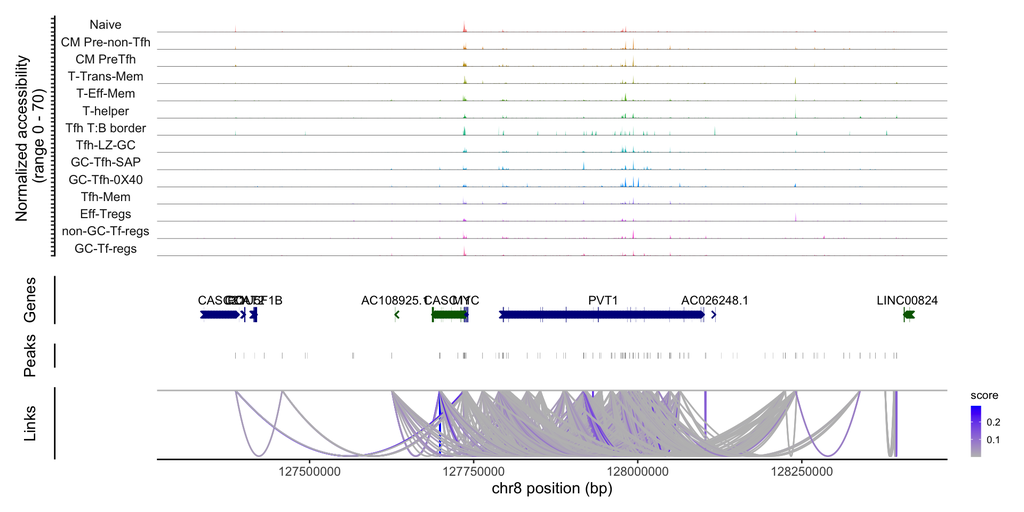

```r
CoveragePlot(
object = seurat,
region = "chr8-127322183-128417210")
```

# 5 Relationship between CCANS and level 1 assigment.

For each cluster, we are going to extract the normalized value of the cells that have a peak in each specific CCAN. We are going to calculate the mean value from all the cells to check if there is any bias toward a certain cell type.

```r
#ccans_split = ccans %>% separate(Peak, c("chr","start","end"))
#ccans_split$end = as.numeric(ccans_split$end)
#ccans_split$start = as.numeric(ccans_split$start)

# For each module, we are going to extract the peaks tha conform it
CCANS_sum = c()
clusters = c()
modules = c()

for (module in unique(ccans_sorted$CCAN)){
peaks <- ccans_sorted[ccans_sorted$CCAN == module,]$Peak

for (clust in unique(seurat@meta.data$annotation_paper)){
cells_cluster = row.names(seurat@meta.data[seurat@meta.data$annotation_paper == clust,])
peaks_data_cluster <- seurat@assays$peaks@data[peaks,cells_cluster]
CCANS_sum = c(CCANS_sum,mean(peaks_data_cluster))
clusters = c(clusters,clust)
modules = c(modules, rep(module,length(clust)))
}
}

CCANS_per_cluster = data.frame(clusters,CCANS_sum,modules)
colnames(CCANS_per_cluster) = c("clusters","CCANS_means","module")
CCANS_per_cluster$module = as.factor(CCANS_per_cluster$module)
CCANS_per_cluster$clusters = as.factor(CCANS_per_cluster$clusters)
head(CCANS_per_cluster)
```

```
##         clusters CCANS_means module
## 1      Tfh-LZ-GC 0.109134593   4905
## 2     GC-Tfh-SAP 0.247379699   4905
## 3 CM Pre-non-Tfh 0.016099469   4905
## 4      Eff-Tregs 0.033301159   4905
## 5          Naive 0.008064106   4905
## 6      CM PreTfh 0.032242481   4905
```

```r
#write.table(x = CCANS_per_cluster,
#file = paste0(path_to_save, "level_1_ccansxcluster.tsv"),
#row.names = F, quote = F)
```

## 5.1 Conversion into matrix and compute the PCA

Now, we can visualize how the different cell types can be related or unrelated by looking at the co-accessible comunities defined by Cicero.

```r
CCANS_per_cluster_mat = acast(CCANS_per_cluster, clusters~module, value.var='CCANS_means')
res.pca <- prcomp(CCANS_per_cluster_mat, scale = TRUE)
```

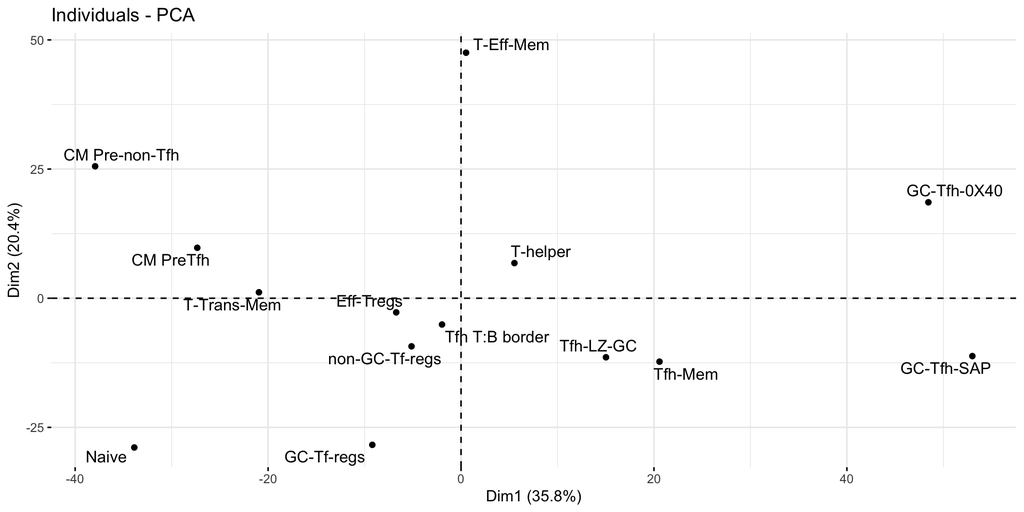

```r
options(repr.plot.width=6, repr.plot.height=8)
fviz_pca_ind(res.pca,
repel = TRUE     # Avoid text overlapping
)
```

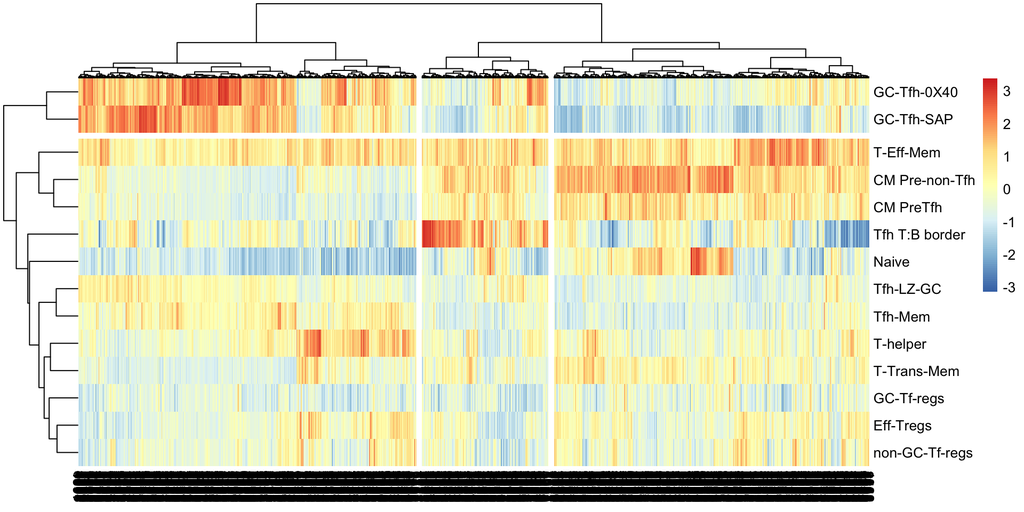

```r
options(repr.plot.width=15, repr.plot.height=6)
out = pheatmap(scale(CCANS_per_cluster_mat),cutree_cols = 3, cutree_rows = 2,
clustering_distance_rows = "euclidean",
clustering_distance_cols = "euclidean",
clustering_method = "ward.D2")
```